## Tips at Restaurants

In this homework we will use the `tips` data set. This data set is part of the `reshape2` package. You can load the data set by executing the command:

```r
data(tips, package="reshape2")

library(tidyverse)
```

If you do not have available the package `reshape2`, issue `install.packages('reshape2')` to install it. The information contained in the data is collected by one waiter, who recorded over the course of a season information about each tip he received working in one restaurant. See `?tips` for a description of all of the variables.

**Submission instructions**: Create a folder named `ds202_hw3`, and name the RMarkDown file `hw3.Rmd` which should include your solutions under this folder. For submission, create a GitHub repository named `ds202_hw3` under your GitHub account, and push both `hw3.Rmd` and the knitted `hw3.html` before the deadline. I will assume you use the same GitHub username as for your HW2 submission. The latest version of your homework appearing on GitHub before the deadline is graded. *It is crucial to follow the exact folder structure and file names*, so that your homework can be reproduced and graded by an automated script. This homework is **due on Feb 19** before class.

# 1. How many parties did the waiter serve? Store the number in `numParty` and print.

```r
numParty <- length(tips$day)
numParty
```

```
## [1] 244
```

The waiter served 244 total parties

# 2. What are the types of variables in the data frame `tips`? Include the code and also explain verbally.

```r
str(tips)
```

```
## 'data.frame':    244 obs. of  7 variables:
##  $ total_bill: num  17 10.3 21 23.7 24.6 ...
##  $ tip       : num  1.01 1.66 3.5 3.31 3.61 4.71 2 3.12 1.96 3.23 ...
##  $ sex       : Factor w/ 2 levels "Female","Male": 1 2 2 2 1 2 2 2 2 2 ...
##  $ smoker    : Factor w/ 2 levels "No","Yes": 1 1 1 1 1 1 1 1 1 1 ...
##  $ day       : Factor w/ 4 levels "Fri","Sat","Sun",..: 3 3 3 3 3 3 3 3 3 3 ...
##  $ time      : Factor w/ 2 levels "Dinner","Lunch": 1 1 1 1 1 1 1 1 1 1 ...
##  $ size      : int  2 3 3 2 4 4 2 4 2 2 ...
```

total_bill and tip are both numeric variables; sex, smoker, day, and time are all factor variables. size is an integer variable.

# 3. Create a vector named `day` containing the day of visits in `tips`. The factor levels should be ordered from Thursday to Sunday. Print the variable.

```r
day <- levels(tips$day)
day
```

```
## [1] "Fri"  "Sat"  "Sun"  "Thur"
```

We need to make Thursday the first day.

```r
levels(tips$day) <- c("Thur", "Fri", "Sat", "Sun")
levels(tips$time) <- c("Lunch", "Dinner")
```

# 4. Create a data frame named `female5` containing the meal paid by a female payer in a party with size greater than or euqal to 5. Print the data frame.

```r
female5 <- tips %>%
  filter(sex == "Female" & size >= 5)

female5
```

```
##   total_bill  tip    sex smoker day   time size
## 1      29.80 4.20 Female     No Sun Dinner    6
## 2      27.05 5.00 Female     No Sun Dinner    6
## 3      29.85 5.14 Female     No Sat  Lunch    5
```

# 5. How does the tipping amount (`tip`) depend on the overall bill (`total_bill`)? Use the `ggplot2` package to make a chart. Describe the relationship in words.

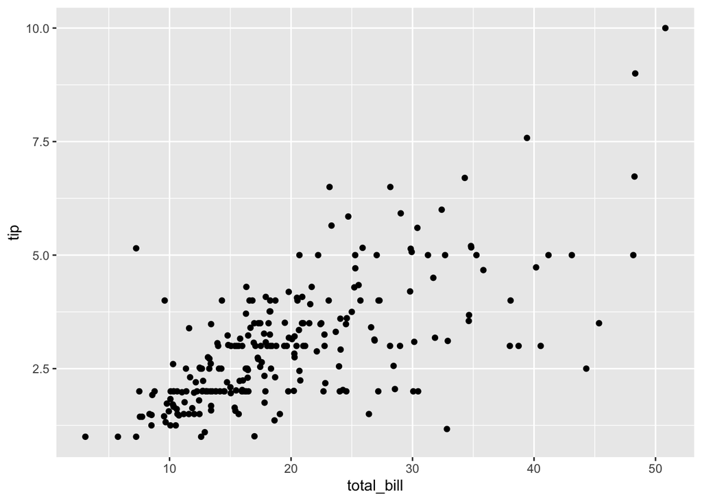

```r
tips %>%
  ggplot(aes(x = total_bill, y = tip)) +
  geom_point()
```

The tipping amound depends a little bit on the total bill. There appears to be a moderate positive relationship between the tipped amount and the total bill.

# 6. Describe at least two types of anomalies in the previous plot. What do they mean?

One anamoly in the plot is the people who are above the normal trend line. There’s one party who tipped about 5 dollars when their bill was only about 7. The other anamoly is the people who tipped well below the trend line. For example, one party only tipped 2.5 dollars when their overall bill is about 45 dollars.

# 7. Introduce a variable `tiprate` into the data set which stands for the rate of tips. What is the average rate for tips? Explain verbally.

```r
tips <- tips %>%
  mutate(tiprate = tip / (total_bill - tip))

mean(tips$tiprate)
```

```
## [1] 0.2021235
```

The average party tips about 20% of their bill.

# 8. Make a boxplot of the tip rate by time. The x-axis should be ordered by lunch and then dinner. Use `ggplot2` to make a chart. Verbally explain the chart.

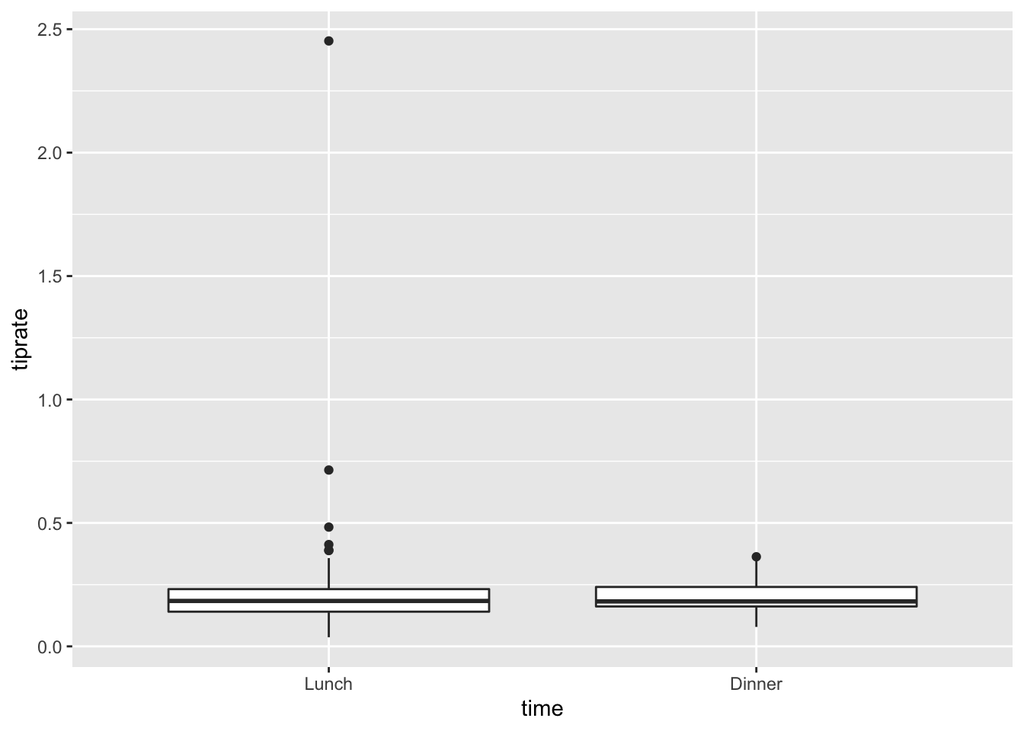

```r
tips %>%
  ggplot(aes(x = time, y = tiprate)) +
  geom_boxplot()
```

# 9. How does smoking behavior and gender of the person who pays impact the relationship between tip and total bill? Find a visualization that incorporates all four variables. Interpret the result.

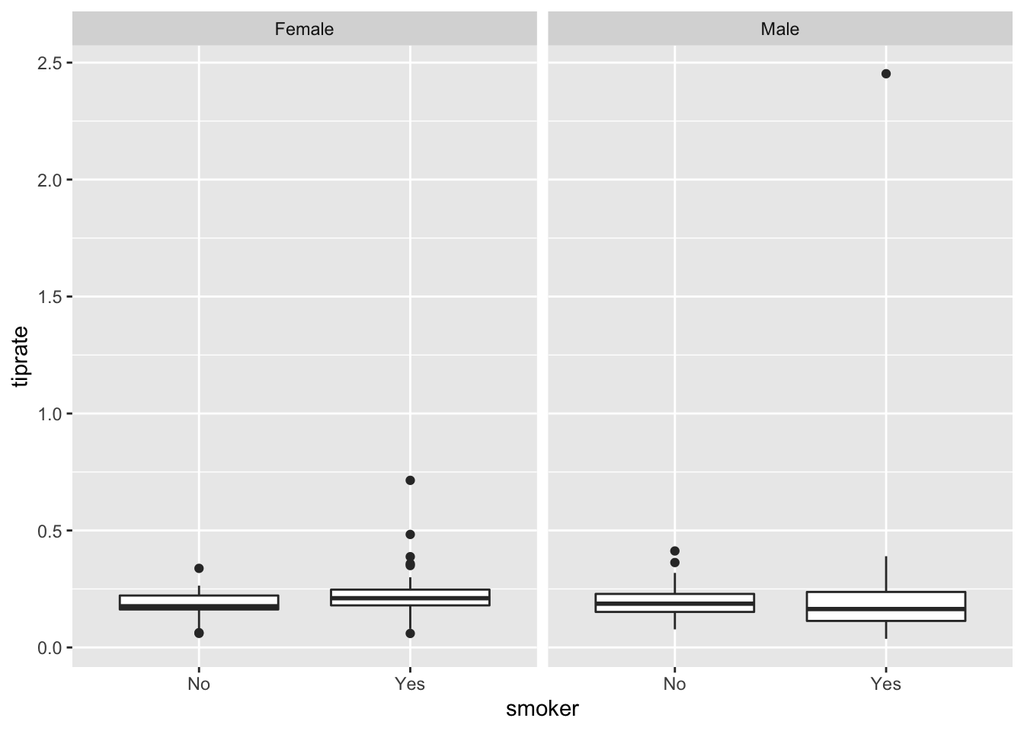

```r
tips %>%
  ggplot(aes(x = smoker, y = tiprate)) +
  geom_boxplot() +
  facet_grid(. ~ sex)
```

There doesn’t seem to be any major differences in the tip rate between smokers/non=smokers and men/women. I did observe a few things, however. There are a lot of outliers in the female smokers box plot. Male smokers have the largest IQR/

# 10. Use ggplot2 to find a graphical summary of the relationship between day of the week and gender of the person paying the bill. What can you say about this relationship?

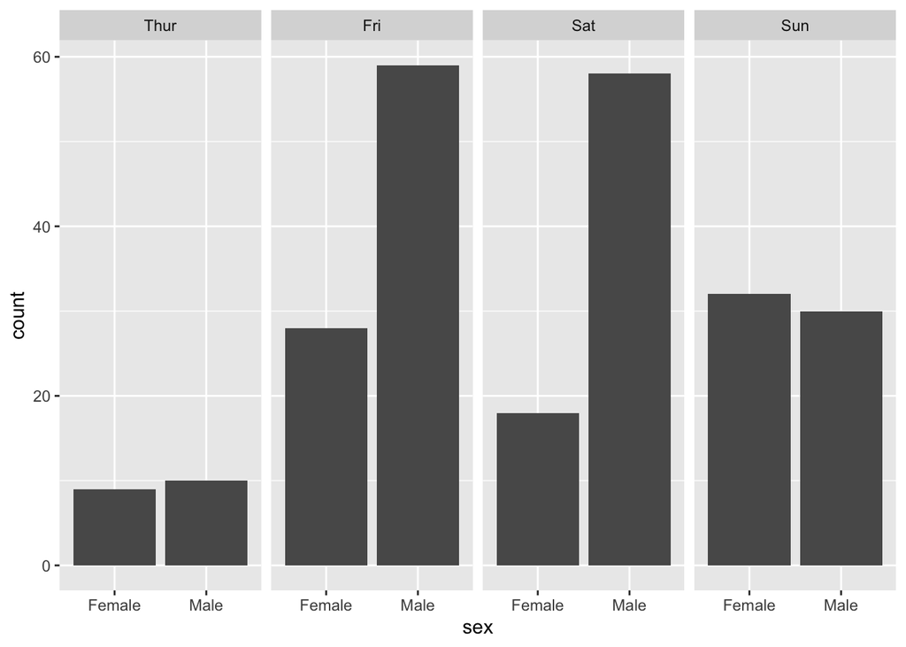

```r
tips %>%
  ggplot(aes(x = sex)) +
  geom_bar() +
  facet_grid(. ~ day)
```

Note: your submission is supposed to be fully reproducible, i.e. the TA and I will ‘knit’ your submission in RStudio.